# BIDS Series Classification: ML Analysis Report

This notebook is a **presentation-quality analysis** of the automated BIDS classification system. It covers:

1. The clinical problem motivating automated series labeling
2. How the heuristic inference pipeline works and what label classes it produces
3. How the XGBoost model was trained and how well it performs overall
4. Per-class and per-family performance, hard classes, and unknown-label coverage

> All data loaded here is pre-computed by `ml.ipynb` and stored in `outputs/`. Re-run `ml.ipynb` then the **"Analysis Data Export"** cell before refreshing results here.

```python
from pathlib import Path
import warnings

import numpy as np
import pandas as pd
import matplotlib.pyplot as plt
import matplotlib.image as mpimg
import matplotlib.patches as mpatches

warnings.filterwarnings("ignore", category=FutureWarning)
pd.set_option("display.max_columns", 40)
pd.set_option("display.float_format", "{:.4f}".format)

plt.rcParams.update({
    "figure.dpi": 130,
    "axes.spines.top": False,
    "axes.spines.right": False,
    "font.size": 11,
    "axes.titlesize": 13,
    "axes.labelsize": 11,
})

# Locate project root (the directory containing src/)
_cwd = Path(".").resolve()
PROJECT_DIR = _cwd
while not (PROJECT_DIR / "src").exists() and PROJECT_DIR.parent != PROJECT_DIR:
    PROJECT_DIR = PROJECT_DIR.parent

ANALYSIS_DATA_DIR = PROJECT_DIR / "outputs" / "analysis_data"
FINAL_METRIC_DIR  = PROJECT_DIR / "outputs" / "plots" / "finalized_model" / "metrics"
CONFUSION_DIR     = PROJECT_DIR / "outputs" / "plots" / "finalized_model" / "confusion"
REVIEW_DIR        = PROJECT_DIR / "outputs" / "review"

_family_palette = {
    "anat": "#2B6CB0", "func": "#48BB78", "dwi": "#9F7AEA",
    "perf": "#ED8936", "fmap": "#38B2AC", "localizer": "#E53E3E",
    "exclude": "#718096", "unknown": "#CBD5E0",
}

print(f"Project root : {PROJECT_DIR}")
print(f"Analysis data: {ANALYSIS_DATA_DIR}")
```

```
Project root : /Users/cmokashi/Documents/GitHub/find_BIDS
Analysis data: /Users/cmokashi/Documents/GitHub/find_BIDS/outputs/analysis_data
```

```python
# Load all pre-computed artifacts
analysis_df    = pd.read_csv(ANALYSIS_DATA_DIR / "heuristic_scores_with_splits.csv")
split_summary  = pd.read_csv(ANALYSIS_DATA_DIR / "split_summary.csv")
final_metrics  = pd.read_csv(FINAL_METRIC_DIR  / "final_model_eval_metrics.csv")
report_test    = pd.read_csv(FINAL_METRIC_DIR  / "classification_report_inferred_joint_label_test.csv")
report_val     = pd.read_csv(FINAL_METRIC_DIR  / "classification_report_inferred_joint_label_val.csv")
unknown_review = pd.read_csv(REVIEW_DIR        / "unknown_joint_label_inference_review.csv")

# Derive the ML-style joint label from heuristic columns
analysis_df["joint_label"] = (
    analysis_df["inferred_datatype"].fillna("unknown").astype(str)
    + "::"
    + analysis_df["inferred_suffix"].fillna("unknown").astype(str)
)
analysis_df["is_heuristic_unknown"] = (
    analysis_df["inferred_datatype"].fillna("").str.lower().str.contains("unknown")
    | analysis_df["inferred_suffix"].fillna("").str.lower().str.contains("unknown")
)

# Use heuristic-unknown flag to separate known vs unknown series
labeled_df  = analysis_df[~analysis_df["is_heuristic_unknown"]].copy()
excluded_df = analysis_df[analysis_df["is_heuristic_unknown"]].copy()

_summary_labels = {"accuracy", "macro avg", "weighted avg"}
class_report = report_test[~report_test["label"].isin(_summary_labels)].copy()
class_report["datatype"] = class_report["label"].str.split("::").str[0]
class_report["support"]  = class_report["support"].astype(int)

print(f"Total series rows          : {len(analysis_df):,}")
print(f"  Heuristic-labeled (known): {len(labeled_df):,}")
print(f"  Heuristic-unknown        : {len(excluded_df):,}")
display(split_summary)
```

```
Total series rows          : 144,358
  Heuristic-labeled (known): 120,998
  Heuristic-unknown        : 23,360
```

|  | split | rows |
| --- | --- | --- |
| 0 | all | 77489 |
| 1 | test | 11622 |
| 2 | train | 45474 |
| 3 | val | 9773 |

## Part 1 — Problem Statement

### The Challenge of BIDS Organization

The [Brain Imaging Data Structure (BIDS)](https://bids.neuroimaging.io/) standard organizes neuroimaging acquisitions by assigning every acquired series a **datatype** (broad scan family: `anat`, `func`, `dwi`, …) and a **suffix** (specific contrast or modality: `T1w`, `bold`, `dwi`, …).

Manual BIDS labeling is:

- **Slow** — a researcher must inspect series descriptions, acquisition parameters, and DICOM metadata for every series
- **Error-prone** — naming conventions vary widely across scanners, sites, and research groups
- **Not scalable** — large multi-site studies routinely contain thousands of series

### Two-Stage Solution

```
DICOM metadata
     │
     ▼
┌─────────────────────┐   high confidence
│  Heuristic Inference │ ──────────────────► BIDS label (fast path)
└─────────────────────┘
     │ low / ambiguous confidence
     ▼
┌─────────────────────┐
│   XGBoost Classifier │ ─────────────────► BIDS label (ML path)
└─────────────────────┘
```

1. **Heuristic inference** — a rule-based engine scores each series against BIDS schema rules, producing a provisional `inferred_datatype` and `inferred_suffix` with an associated `min_confidence` score.
2. **ML correction** — an XGBoost classifier trained on high-confidence heuristic labels helps classify ambiguous series. It predicts the **joint label** `inferred_datatype::inferred_suffix` (e.g., `anat::T1w`, `dwi::dwi`, `fmap::fieldmap`).

## Part 2 — The Heuristic Inference Pipeline

### Label Space

The system classifies every series into one of the following `datatype::suffix` combinations:

| Datatype | Description | Key Suffixes |
| --- | --- | --- |
| `anat` | Structural / anatomical scans | T1w, T2w, FLAIR, T2starw, PDw, angio |
| `func` | Functional MRI | bold, sbref, funcStatMap, funcTimeSeries |
| `dwi` | Diffusion-weighted imaging | dwi, sbref |
| `perf` | Perfusion / ASL imaging | m0scan, perfCbfLikeMap, perfCbvLikeMap, perfTimingMap |
| `fmap` | Field maps | fieldmap, magnitude, phasediff, epi, fmapSusceptibilityOrPhaseMap |
| `localizer` | Scout / planning scans | localizer |
| `unknown` | Series the heuristic engine cannot classify | unknown |

### Confidence Score

Each heuristic assignment carries a `min_confidence` score ∈ [0, 1] — the minimum of the datatype and suffix confidence scores. Rows where `min_confidence` is low *or* where either label part is `unknown` are the primary target of the ML correction step.

```python
# Class catalog: unique joint labels in the ML-labeled portion of the dataset
train_classes = sorted(labeled_df["joint_label"].dropna().unique().tolist())
catalog_rows = []
for jl in train_classes:
    parts = jl.split("::")
    catalog_rows.append({"datatype": parts[0], "suffix": parts[1] if len(parts) > 1 else "", "joint_label": jl})
catalog_df = pd.DataFrame(catalog_rows)

family_catalog = (
    catalog_df.groupby("datatype")["suffix"]
    .apply(list)
    .reset_index()
    .rename(columns={"suffix": "suffixes"})
)
family_catalog["n_suffixes"] = family_catalog["suffixes"].apply(len)
family_catalog["suffixes"]   = family_catalog["suffixes"].apply(lambda s: ", ".join(s))

print(f"Total joint-label classes in labeled data: {len(train_classes)}")
display(family_catalog)
```

```
Total joint-label classes in labeled data: 28
```

|  | datatype | suffixes | n_suffixes |
| --- | --- | --- | --- |
| 0 | anat | FLAIR, PD, SWI, T1w, T2starw, T2w, anatReforma... | 8 |
| 1 | dwi | dwi, dwiOtherDerived, dwiParamMap, dwiSegmenta... | 4 |
| 2 | fmap | epi, fmapOtherDerived, fmapReformat, fmapSegme... | 7 |
| 3 | func | bold, funcStatMap, sbref | 3 |
| 4 | localizer | localizer | 1 |
| 5 | perf | dce, dsc, perfCbfLikeMap, perfCbvLikeMap, perf... | 5 |

## Part 2B — Heuristic vs ML Shift Analysis

This section quantifies how ML changes predictions relative to the heuristic engine on the comparable population (`ml_split == "all"` with both labels and confidences present).

We evaluate:

- Continuous confidence shift: `ml_pred_confidence - min_confidence`
- Full joint-label changes: `heuristic_joint_label != ml_pred_joint_label`
- Data-driven confidence blocks from quantile bins

```python
# Build comparable heuristic vs ML frame (deduplicated by using ml_split == "all")
comp_df = analysis_df[
    (analysis_df["ml_split"] == "all")
    & analysis_df["min_confidence"].notna()
    & analysis_df["ml_pred_confidence"].notna()
    & analysis_df["joint_label"].notna()
    & analysis_df["ml_pred_joint_label"].notna()
].copy()

def _normalize_joint_label(lbl):
    if pd.isna(lbl):
        return np.nan
    s = str(lbl).strip()
    if "::" in s:
        return s
    if "_" in s:
        left, right = s.split("_", 1)
        return f"{left}::{right}"
    return s

comp_df["heuristic_joint_label"] = comp_df["joint_label"].map(_normalize_joint_label)
comp_df["ml_joint_label"] = comp_df["ml_pred_joint_label"].map(_normalize_joint_label)
comp_df["confidence_delta"] = comp_df["ml_pred_confidence"] - comp_df["min_confidence"]
comp_df["abs_delta"] = comp_df["confidence_delta"].abs()
comp_df["label_changed"] = comp_df["heuristic_joint_label"] != comp_df["ml_joint_label"]
comp_df["delta_direction"] = np.select(
    [
        comp_df["confidence_delta"] > 0,
        comp_df["confidence_delta"] < 0,
    ],
    ["boosted", "reduced"],
    default="unchanged",
)

n_total = len(comp_df)
n_changed = int(comp_df["label_changed"].sum())
n_boosted = int((comp_df["confidence_delta"] > 0).sum())
n_reduced = int((comp_df["confidence_delta"] < 0).sum())
n_tied = int((comp_df["confidence_delta"] == 0).sum())

headline = pd.DataFrame([
    {
        "comparable_rows": n_total,
        "changed_labels": n_changed,
        "changed_rate": n_changed / n_total if n_total else np.nan,
        "boosted_confidence": n_boosted,
        "boosted_rate": n_boosted / n_total if n_total else np.nan,
        "reduced_confidence": n_reduced,
        "reduced_rate": n_reduced / n_total if n_total else np.nan,
        "unchanged_confidence": n_tied,
        "unchanged_conf_rate": n_tied / n_total if n_total else np.nan,
        "delta_mean": float(comp_df["confidence_delta"].mean()) if n_total else np.nan,
        "delta_median": float(comp_df["confidence_delta"].median()) if n_total else np.nan,
    }
])

print("Comparable population built (ml_split == 'all').")
display(headline.style.format({
    "changed_rate": "{:.2%}",
    "boosted_rate": "{:.2%}",
    "reduced_rate": "{:.2%}",
    "unchanged_conf_rate": "{:.2%}",
    "delta_mean": "{:.4f}",
    "delta_median": "{:.4f}",
}))
```

```
Comparable population built (ml_split == 'all').
```

|  | comparable_rows | changed_labels | changed_rate | boosted_confidence | boosted_rate | reduced_confidence | reduced_rate | unchanged_confidence | unchanged_conf_rate | delta_mean | delta_median |
| --- | --- | --- | --- | --- | --- | --- | --- | --- | --- | --- | --- |
| 0 | 21395 | 18722 | 87.51% | 20980 | 98.06% | 415 | 1.94% | 0 | 0.00% | 0.4449 | 0.3193 |

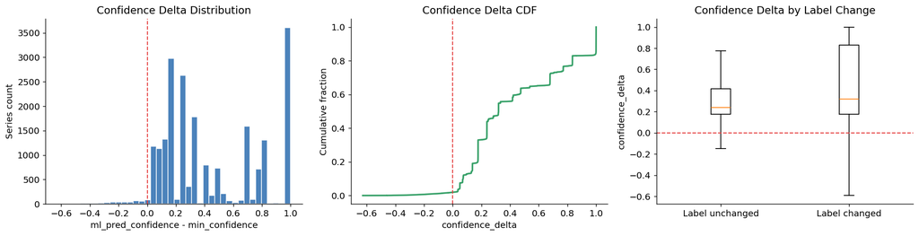

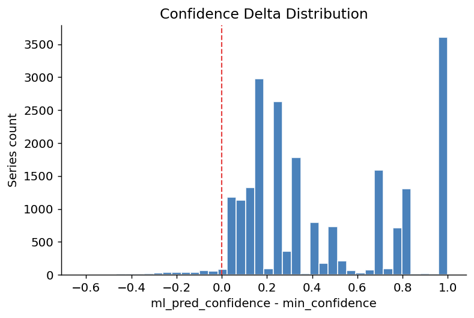

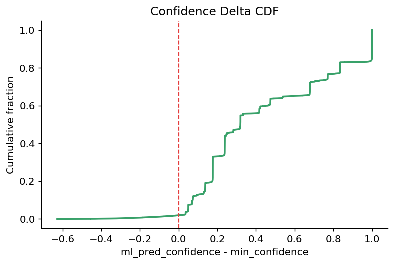

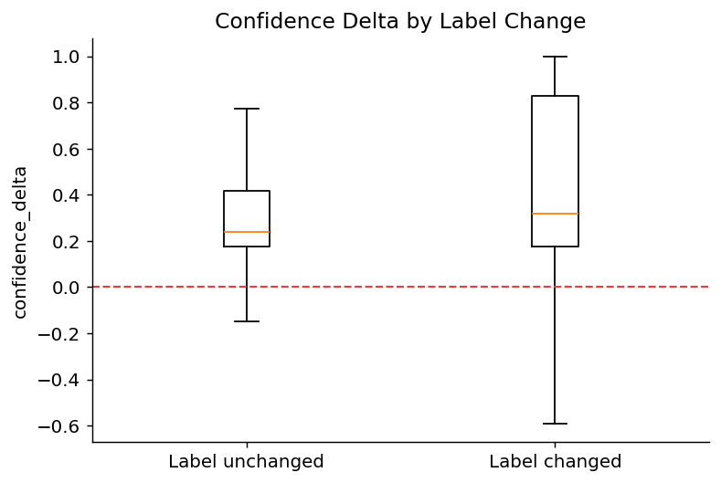

```
Confidence-delta summary:
```

|  | count | mean | std | min | 5% | 10% | 25% | 50% | 75% | 90% | 95% | max | positive_rate | negative_rate | zero_rate |
| --- | --- | --- | --- | --- | --- | --- | --- | --- | --- | --- | --- | --- | --- | --- | --- |
| confidence_delta | 21395.000000 | 0.4449 | 0.3420 | -0.6273 | 0.0497 | 0.0726 | 0.1767 | 0.3193 | 0.7708 | 0.9999 | 1.0000 | 1.0000 | 98.06% | 1.94% | 0.00% |

```
Data-driven confidence blocks (quantile bins):
```

|  | delta_block | rows | changed_rows | changed_rate | delta_median | delta_q25 | delta_q75 | delta_mean | delta_min | delta_max |
| --- | --- | --- | --- | --- | --- | --- | --- | --- | --- | --- |
| 0 | (-0.628, 0.137] | 3566 | 3015 | 84.55% | 0.0688 | 0.0489 | 0.0948 | 0.0497 | -0.6273 | 0.1375 |
| 1 | (0.137, 0.221] | 3566 | 2901 | 81.35% | 0.1767 | 0.1760 | 0.1768 | 0.1710 | 0.1375 | 0.2208 |
| 2 | (0.221, 0.319] | 3566 | 2977 | 83.48% | 0.2384 | 0.2383 | 0.2782 | 0.2562 | 0.2209 | 0.3193 |
| 3 | (0.319, 0.678] | 3566 | 3190 | 89.46% | 0.4172 | 0.3195 | 0.4743 | 0.4309 | 0.3193 | 0.6782 |
| 4 | (0.678, 0.983] | 3565 | 3105 | 87.10% | 0.7708 | 0.6785 | 0.8347 | 0.7622 | 0.6782 | 0.9825 |
| 5 | (0.983, 1.0] | 3566 | 3534 | 99.10% | 0.9999 | 0.9998 | 1.0000 | 0.9995 | 0.9830 | 1.0000 |

```python
# Confidence-delta distribution and data-driven blocks
delta_desc = comp_df["confidence_delta"].describe(percentiles=[0.05, 0.10, 0.25, 0.50, 0.75, 0.90, 0.95]).to_frame().T
delta_desc["positive_rate"] = (comp_df["confidence_delta"] > 0).mean()
delta_desc["negative_rate"] = (comp_df["confidence_delta"] < 0).mean()
delta_desc["zero_rate"] = (comp_df["confidence_delta"] == 0).mean()

# Shared arrays
delta_vals = comp_df["confidence_delta"].to_numpy()
delta_sorted = np.sort(delta_vals)
cdf_y = np.arange(1, len(delta_sorted) + 1) / len(delta_sorted)

_chg = comp_df.loc[comp_df["label_changed"], "confidence_delta"]
_same = comp_df.loc[~comp_df["label_changed"], "confidence_delta"]

# ------------------------------------------------------------
# Combined 3-panel figure (kept as `fig` for downstream save)
# ------------------------------------------------------------
fig, axes = plt.subplots(1, 3, figsize=(16, 4.2))

# Histogram
axes[0].hist(delta_vals, bins=40, color="#2B6CB0", alpha=0.85, edgecolor="white")
axes[0].axvline(0, color="#E53E3E", linestyle="--", linewidth=1.2)
axes[0].set_title("Confidence Delta Distribution")
axes[0].set_xlabel("ml_pred_confidence - min_confidence")
axes[0].set_ylabel("Series count")

# Empirical CDF
axes[1].plot(delta_sorted, cdf_y, color="#38A169", linewidth=2)
axes[1].axvline(0, color="#E53E3E", linestyle="--", linewidth=1.2)
axes[1].set_title("Confidence Delta CDF")
axes[1].set_xlabel("confidence_delta")
axes[1].set_ylabel("Cumulative fraction")

# Changed vs unchanged boxplot
axes[2].boxplot([_same, _chg], tick_labels=["Label unchanged", "Label changed"], showfliers=False)
axes[2].axhline(0, color="#E53E3E", linestyle="--", linewidth=1.2)
axes[2].set_title("Confidence Delta by Label Change")
axes[2].set_ylabel("confidence_delta")

plt.tight_layout()
plt.show()

# ------------------------------------------------------------
# Standalone figures (for presentation reuse)
# ------------------------------------------------------------
fig_hist, ax_hist = plt.subplots(figsize=(6.2, 4.2))
ax_hist.hist(delta_vals, bins=40, color="#2B6CB0", alpha=0.85, edgecolor="white")
ax_hist.axvline(0, color="#E53E3E", linestyle="--", linewidth=1.2)
ax_hist.set_title("Confidence Delta Distribution")
ax_hist.set_xlabel("ml_pred_confidence - min_confidence")
ax_hist.set_ylabel("Series count")
plt.tight_layout()
plt.show()

fig_cdf, ax_cdf = plt.subplots(figsize=(6.2, 4.2))
ax_cdf.plot(delta_sorted, cdf_y, color="#38A169", linewidth=2)
ax_cdf.axvline(0, color="#E53E3E", linestyle="--", linewidth=1.2)
ax_cdf.set_title("Confidence Delta CDF")
ax_cdf.set_xlabel("ml_pred_confidence - min_confidence")
ax_cdf.set_ylabel("Cumulative fraction")
plt.tight_layout()
plt.show()

fig_box, ax_box = plt.subplots(figsize=(6.2, 4.2))
ax_box.boxplot([_same, _chg], tick_labels=["Label unchanged", "Label changed"], showfliers=False)
ax_box.axhline(0, color="#E53E3E", linestyle="--", linewidth=1.2)
ax_box.set_title("Confidence Delta by Label Change")
ax_box.set_ylabel("confidence_delta")
plt.tight_layout()
plt.show()

# Quantile blocks (adaptive if duplicate edges occur)
n_bins_target = 6
n_unique = int(comp_df["confidence_delta"].nunique())
n_bins = max(2, min(n_bins_target, n_unique))
comp_df["delta_block"] = pd.qcut(comp_df["confidence_delta"], q=n_bins, duplicates="drop")

block_summary = (
    comp_df.groupby("delta_block", observed=True)
    .agg(
        rows=("series_id", "count"),
        changed_rows=("label_changed", "sum"),
        changed_rate=("label_changed", "mean"),
        delta_median=("confidence_delta", "median"),
        delta_q25=("confidence_delta", lambda s: s.quantile(0.25)),
        delta_q75=("confidence_delta", lambda s: s.quantile(0.75)),
        delta_mean=("confidence_delta", "mean"),
        delta_min=("confidence_delta", "min"),
        delta_max=("confidence_delta", "max"),
    )
    .reset_index()
    .sort_values("delta_median")
)

print("Confidence-delta summary:")
display(delta_desc.style.format({
    "mean": "{:.4f}", "std": "{:.4f}", "min": "{:.4f}", "5%": "{:.4f}",
    "10%": "{:.4f}", "25%": "{:.4f}", "50%": "{:.4f}", "75%": "{:.4f}",
    "90%": "{:.4f}", "95%": "{:.4f}", "max": "{:.4f}",
    "positive_rate": "{:.2%}", "negative_rate": "{:.2%}", "zero_rate": "{:.2%}",
}))

print("\nData-driven confidence blocks (quantile bins):")
display(block_summary.style.format({
    "changed_rate": "{:.2%}",
    "delta_median": "{:.4f}",
    "delta_q25": "{:.4f}",
    "delta_q75": "{:.4f}",
    "delta_mean": "{:.4f}",
    "delta_min": "{:.4f}",
    "delta_max": "{:.4f}",
}))
```

```python
# Label-change transitions and artifact export
transition_counts = (
    comp_df[comp_df["label_changed"]]
    .groupby(["heuristic_joint_label", "ml_joint_label"], observed=True)
    .size()
    .rename("rows")
    .reset_index()
    .sort_values("rows", ascending=False)
)
top_transitions = transition_counts.head(20).copy()

group_stats = (
    comp_df.groupby("label_changed", observed=True)["confidence_delta"]
    .agg(["count", "mean", "median", "std", "min", "max"])
    .reset_index()
)
group_stats["label_changed"] = group_stats["label_changed"].map({False: "unchanged", True: "changed"})

analysis_plot_dir = PROJECT_DIR / "outputs" / "plots" / "analysis"
analysis_plot_dir.mkdir(parents=True, exist_ok=True)

confidence_summary_path = ANALYSIS_DATA_DIR / "ml_vs_heuristic_confidence_delta_summary.csv"
block_summary_path = ANALYSIS_DATA_DIR / "ml_vs_heuristic_delta_blocks_summary.csv"
transition_path = ANALYSIS_DATA_DIR / "ml_vs_heuristic_label_change_transitions.csv"
group_stats_path = ANALYSIS_DATA_DIR / "ml_vs_heuristic_label_change_group_stats.csv"
headline_path = ANALYSIS_DATA_DIR / "ml_vs_heuristic_headline_metrics.csv"
figure_path = analysis_plot_dir / "ml_vs_heuristic_confidence_delta_overview.png"

delta_desc.to_csv(confidence_summary_path, index=False)
block_summary.to_csv(block_summary_path, index=False)
transition_counts.to_csv(transition_path, index=False)
group_stats.to_csv(group_stats_path, index=False)
headline.to_csv(headline_path, index=False)
fig.savefig(figure_path, bbox_inches="tight")
plt.close(fig)

print("Top heuristic -> ML label transitions (changed rows):")
display(top_transitions)

print("\nChanged vs unchanged confidence-delta stats:")
display(group_stats.style.format({
    "mean": "{:.4f}",
    "median": "{:.4f}",
    "std": "{:.4f}",
    "min": "{:.4f}",
    "max": "{:.4f}",
}))

print("\nSaved artifacts:")
print(f"- {headline_path}")
print(f"- {confidence_summary_path}")
print(f"- {block_summary_path}")
print(f"- {transition_path}")
print(f"- {group_stats_path}")
print(f"- {figure_path}")
```

```
Top heuristic -> ML label transitions (changed rows):
```

|  | heuristic_joint_label | ml_joint_label | rows |
| --- | --- | --- | --- |
| 118 | dwi::dwi | anat::T1w | 898 |
| 41 | anat::T1w | dwi::dwi | 699 |
| 246 | localizer::localizer | dwi::dwi | 656 |
| 123 | dwi::dwi | dwi::dwiParamMap | 615 |
| 130 | dwi::dwi | localizer::localizer | 602 |
| 157 | dwi::dwiParamMap | dwi::dwi | 545 |
| 122 | dwi::dwi | dwi::dwiOtherDerived | 441 |
| 242 | localizer::localizer | anat::T1w | 402 |
| 185 | dwi::unknown | dwi::dwi | 386 |
| 141 | dwi::dwiOtherDerived | dwi::dwi | 369 |
| 153 | dwi::dwiParamMap | anat::T1w | 355 |
| 50 | anat::T1w | localizer::localizer | 350 |
| 132 | dwi::dwi | perf::dsc | 338 |
| 43 | anat::T1w | dwi::dwiParamMap | 327 |
| 6 | anat::FLAIR | dwi::dwi | 321 |
| 115 | dwi::dwi | anat::FLAIR | 299 |
| 277 | perf::dsc | dwi::dwi | 292 |
| 248 | localizer::localizer | dwi::dwiParamMap | 289 |
| 104 | anat::unknown | dwi::dwi | 285 |
| 181 | dwi::unknown | anat::T1w | 260 |

```
Changed vs unchanged confidence-delta stats:
```

|  | label_changed | count | mean | median | std | min | max |
| --- | --- | --- | --- | --- | --- | --- | --- |
| 0 | unchanged | 2673 | 0.3106 | 0.2383 | 0.2563 | -0.6273 | 1.0000 |
| 1 | changed | 18722 | 0.4641 | 0.3195 | 0.3483 | -0.5927 | 1.0000 |

```
Saved artifacts:
- /Users/cmokashi/Documents/GitHub/find_BIDS/outputs/analysis_data/ml_vs_heuristic_headline_metrics.csv
- /Users/cmokashi/Documents/GitHub/find_BIDS/outputs/analysis_data/ml_vs_heuristic_confidence_delta_summary.csv
- /Users/cmokashi/Documents/GitHub/find_BIDS/outputs/analysis_data/ml_vs_heuristic_delta_blocks_summary.csv
- /Users/cmokashi/Documents/GitHub/find_BIDS/outputs/analysis_data/ml_vs_heuristic_label_change_transitions.csv
- /Users/cmokashi/Documents/GitHub/find_BIDS/outputs/analysis_data/ml_vs_heuristic_label_change_group_stats.csv
- /Users/cmokashi/Documents/GitHub/find_BIDS/outputs/plots/analysis/ml_vs_heuristic_confidence_delta_overview.png
```

## Part 3 — Dataset Overview

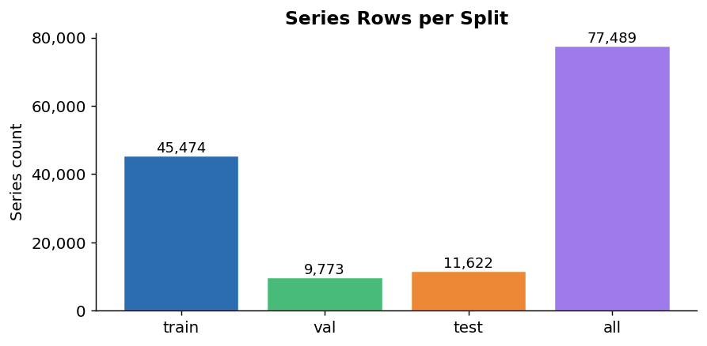

```python
# Split size bar chart  ("all" = full labeled pool used for the final production model)
_split_order  = ["train", "val", "test", "all"]
_split_colors = {"train": "#2B6CB0", "val": "#48BB78", "test": "#ED8936", "all": "#9F7AEA"}

split_plot_df = split_summary.copy()
split_plot_df["split"] = pd.Categorical(split_plot_df["split"], categories=_split_order, ordered=True)
split_plot_df = split_plot_df.sort_values("split").dropna(subset=["split"])

fig, ax = plt.subplots(figsize=(7, 3.5))
colors = [_split_colors.get(str(s), "#718096") for s in split_plot_df["split"]]
bars = ax.bar(split_plot_df["split"].astype(str), split_plot_df["rows"], color=colors, edgecolor="white", linewidth=0.8)
for bar, val in zip(bars, split_plot_df["rows"]):
    ax.text(bar.get_x() + bar.get_width() / 2, bar.get_height() + 80, f"{int(val):,}",
            ha="center", va="bottom", fontsize=10)
ax.set_title("Series Rows per Split", fontweight="bold")
ax.set_ylabel("Series count")
ax.yaxis.set_major_formatter(plt.FuncFormatter(lambda x, _: f"{int(x):,}"))
plt.tight_layout()
plt.show()
plt.close(fig)
```

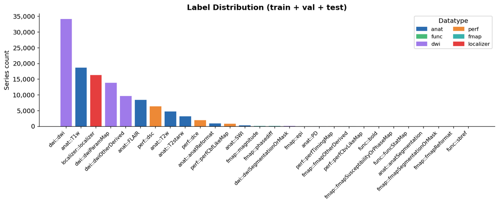

```
Classes present: 28
```

|  | joint_label | count | datatype |
| --- | --- | --- | --- |
| 0 | dwi::dwi | 34184 | dwi |
| 1 | anat::T1w | 18710 | anat |
| 2 | localizer::localizer | 16340 | localizer |
| 3 | dwi::dwiParamMap | 13882 | dwi |
| 4 | dwi::dwiOtherDerived | 9672 | dwi |
| 5 | anat::FLAIR | 8505 | anat |
| 6 | perf::dsc | 6453 | perf |
| 7 | anat::T2w | 4772 | anat |
| 8 | anat::T2starw | 3307 | anat |
| 9 | perf::dce | 2060 | perf |
| 10 | anat::anatReformat | 958 | anat |
| 11 | perf::perfCbfLikeMap | 851 | perf |

```python
# Label distribution across train + val + test
vc = labeled_df["joint_label"].value_counts()
label_counts = pd.DataFrame({"joint_label": vc.index, "count": vc.values})
label_counts["datatype"] = label_counts["joint_label"].str.split("::").str[0]
label_counts = label_counts.sort_values("count", ascending=False)

bar_colors = [_family_palette.get(d, "#A0AEC0") for d in label_counts["datatype"]]

fig, ax = plt.subplots(figsize=(12, 5))
ax.bar(range(len(label_counts)), label_counts["count"], color=bar_colors, edgecolor="white", linewidth=0.5)
ax.set_xticks(range(len(label_counts)))
ax.set_xticklabels(label_counts["joint_label"], rotation=45, ha="right", fontsize=8.5)
ax.set_ylabel("Series count")
ax.set_title("Label Distribution (train + val + test)", fontweight="bold")
ax.yaxis.set_major_formatter(plt.FuncFormatter(lambda x, _: f"{int(x):,}"))
legend_patches = [
    mpatches.Patch(color=c, label=f)
    for f, c in _family_palette.items()
    if f in label_counts["datatype"].values
]
ax.legend(handles=legend_patches, title="Datatype", loc="upper right", fontsize=9, ncol=2)
plt.tight_layout()
plt.show()
plt.close(fig)

print(f"Classes present: {len(label_counts)}")
display(label_counts.head(12))
```

```python
# Per-dataset breakdown
if "dataset" in analysis_df.columns:
    dataset_summary = (
        analysis_df.groupby("dataset")
        .agg(
            total_series=("series_id", "count"),
            unique_subjects=("subject_id", "nunique"),
            unknown_series=("is_heuristic_unknown", "sum"),
        )
        .reset_index()
        .sort_values("total_series", ascending=False)
    )
    dataset_summary["unknown_pct"] = (
        dataset_summary["unknown_series"] / dataset_summary["total_series"] * 100
    ).round(1)
    print("Per-dataset summary:")
    display(dataset_summary)
```

```
Per-dataset summary:
```

|  | dataset | total_series | unique_subjects | unknown_series | unknown_pct |
| --- | --- | --- | --- | --- | --- |
| 0 | proactive | 79153 | 174 | 11403 | 14.4000 |
| 1 | qiac | 65205 | 516 | 11957 | 18.3000 |

## Part 4 — Heuristic Confidence Analysis

Before the ML model runs, the heuristic engine assigns a `min_confidence` score to every series. The plots below show:

- How confidence distributes across labeled vs. unknown-label series
- How the unknown rate changes across confidence buckets (lower confidence → more unknowns)

Series where `min_confidence` is near zero or either label part is `unknown` are the **ML candidates** — they are excluded from supervised training and instead scored by the fitted model.

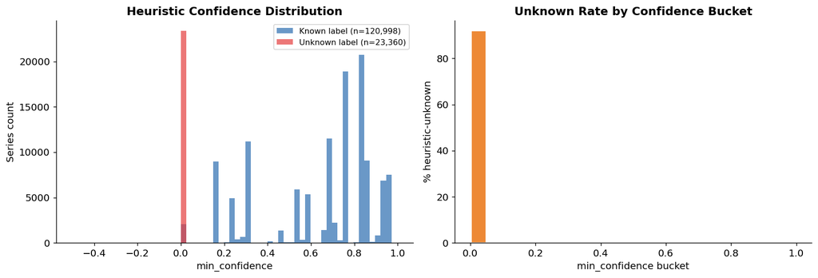

```
Heuristic-unknown series: 23,360 / 144,358  (16.2%)
Median confidence (known): 0.7616
Median confidence (unknown): 0.0000
```

```python
fig, axes = plt.subplots(1, 2, figsize=(13, 4.5))

# Left: confidence histogram, known vs unknown
ax = axes[0]
conf_known   = labeled_df["min_confidence"].dropna()
conf_unknown = excluded_df["min_confidence"].dropna()
ax.hist(conf_known,   bins=40, alpha=0.7, color="#2B6CB0", label=f"Known label (n={len(conf_known):,})")
ax.hist(conf_unknown, bins=40, alpha=0.7, color="#E53E3E", label=f"Unknown label (n={len(conf_unknown):,})")
ax.set_xlabel("min_confidence")
ax.set_ylabel("Series count")
ax.set_title("Heuristic Confidence Distribution", fontweight="bold")
ax.legend(fontsize=9)

# Right: unknown rate per confidence bucket
ax2 = axes[1]
conf_series  = analysis_df["min_confidence"].dropna()
unk_series   = analysis_df.loc[analysis_df["min_confidence"].notna(), "is_heuristic_unknown"]
bins         = np.linspace(0, 1, 21)
bin_idx      = np.digitize(conf_series, bins) - 1
bin_rates, bin_centers = [], []
for b in range(len(bins) - 1):
    mask = bin_idx == b
    if mask.sum() > 0:
        bin_rates.append(unk_series[mask].mean() * 100)
        bin_centers.append((bins[b] + bins[b + 1]) / 2)
ax2.bar(bin_centers, bin_rates, width=0.045, color="#ED8936", edgecolor="white")
ax2.set_xlabel("min_confidence bucket")
ax2.set_ylabel("% heuristic-unknown")
ax2.set_title("Unknown Rate by Confidence Bucket", fontweight="bold")

plt.tight_layout()
plt.show()
plt.close(fig)

total     = len(analysis_df)
n_unknown = int(analysis_df["is_heuristic_unknown"].sum())
print(f"Heuristic-unknown series: {n_unknown:,} / {total:,}  ({n_unknown/total*100:.1f}%)")
print(f"Median confidence (known): {conf_known.median():.4f}")
print(f"Median confidence (unknown): {conf_unknown.median():.4f}")
```

## Part 5 — ML Model Configuration

| Setting | Value |
| --- | --- |
| Model family | `XGBClassifier` |
| Configuration | `xgboost_depth6` (350 estimators, max_depth=6, learning_rate=0.08) |
| Target | `inferred_joint_label` (`dtype::suffix`) |
| Training regime | Confidence-weighted (`min_confidence` as `sample_weight`) |
| Weight floor | 0.30 — low-confidence samples get at least 30% weight |
| Unknown exclusion | `drop_unknown_in_train_val=True` — unknown-label rows held out of train+val |
| Split fractions | 70% train / 15% val / 15% test (`random_state=42`) |
| Feature types | TF-IDF text, keyword flags, engineered numerics, missing indicators |

**Why confidence weighting?** Series where the heuristic engine is uncertain carry noisier labels. Downweighting these rows (without discarding them) keeps the model from over-fitting to low-quality training signal while still benefiting from the additional data volume.

```python
display(final_metrics[[
    "target", "split", "rows", "classes_in_train", "weighted_training"
]])
```

|  | target | split | rows | classes_in_train | weighted_training |
| --- | --- | --- | --- | --- | --- |
| 0 | inferred_joint_label | test | 11622 | 28 | True |
| 1 | inferred_joint_label | val | 9773 | 28 | True |

## Part 6 — Overall Performance

### Metric Summary (Validation vs Test)

| Metric | Description | Validation | Test |
| --- | --- | --- | --- |
| **Accuracy** | Overall fraction of correctly classified series | **0.9958** | **0.9951** |
| **Balanced Accuracy** | Mean recall across classes (treats common and rare classes equally) | **0.8464** | **0.7983** |
| **Macro F1** | Unweighted average F1 across classes (sensitive to rare-class performance) | **0.8383** | **0.7842** |
| **Macro OvR AUC** | One-vs-rest ROC AUC averaged across classes | **0.9998** | **0.9993** |
| **Log Loss** *(lower is better)* | Penalized probability error; lower means better-calibrated confident predictions | **0.0184** | **0.0159** |
| **Top-2 Accuracy** | Fraction where the true class is within the top 2 predicted classes | **0.9989** | **0.9989** |
| **Top-3 Accuracy** | Fraction where the true class is within the top 3 predicted classes | **0.9995** | **0.9993** |

### Interpretation

The model delivers **very strong overall performance** on both splits (accuracy ≈ 99.5%, macro AUC ≈ 0.999).  
The lower **macro F1** and **balanced accuracy** indicate that remaining errors are concentrated in a small number of **rare classes**, rather than the frequent classes.

```python
# Headline metrics table
_metric_cols = [
    "split", "accuracy", "balanced_accuracy", "f1_macro",
    "auc_macro_ovr", "log_loss", "top2_accuracy", "top3_accuracy",
]
headline = final_metrics[_metric_cols].copy()
headline["split"] = pd.Categorical(headline["split"], categories=["val", "test"], ordered=True)
headline = headline.sort_values("split")

display(headline.style
    .format({c: "{:.4f}" for c in _metric_cols[1:]})
    .background_gradient(subset=["accuracy", "f1_macro", "auc_macro_ovr"], cmap="Blues")
    .set_caption("Final Model — Validation and Test Metrics")
)
```

Final Model — Validation and Test Metrics

|  | split | accuracy | balanced_accuracy | f1_macro | auc_macro_ovr | log_loss | top2_accuracy | top3_accuracy |
| --- | --- | --- | --- | --- | --- | --- | --- | --- |
| 1 | val | 0.9958 | 0.8464 | 0.8383 | 0.9998 | 0.0184 | 0.9989 | 0.9995 |
| 0 | test | 0.9951 | 0.7983 | 0.7842 | 0.9993 | 0.0159 | 0.9989 | 0.9993 |

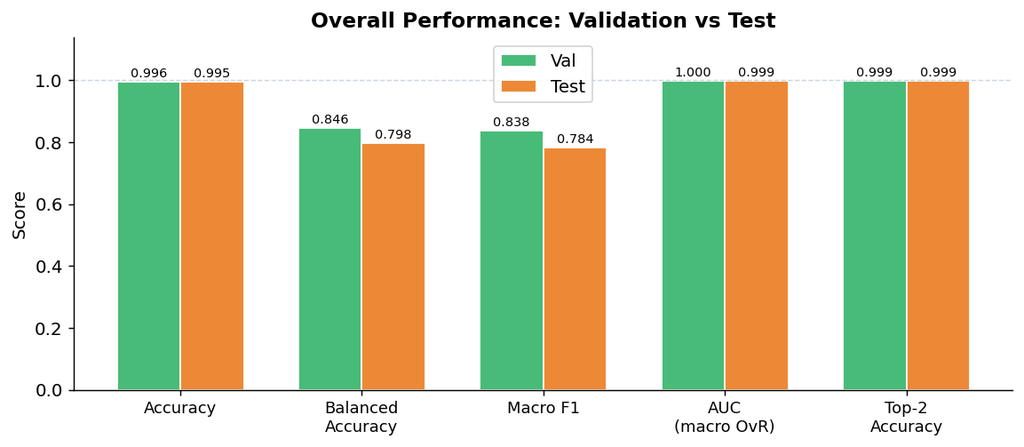

```python
# Grouped bar chart: val vs test on key metrics
_plot_metrics  = ["accuracy", "balanced_accuracy", "f1_macro", "auc_macro_ovr", "top2_accuracy"]
_metric_labels = ["Accuracy", "Balanced\nAccuracy", "Macro F1", "AUC\n(macro OvR)", "Top-2\nAccuracy"]

val_row  = headline[headline["split"] == "val"].iloc[0]
test_row = headline[headline["split"] == "test"].iloc[0]

x, width = np.arange(len(_plot_metrics)), 0.35
fig, ax = plt.subplots(figsize=(9, 4))
ax.bar(x - width/2, [val_row[m]  for m in _plot_metrics], width, label="Val",  color="#48BB78", edgecolor="white")
ax.bar(x + width/2, [test_row[m] for m in _plot_metrics], width, label="Test", color="#ED8936", edgecolor="white")
for xi, m in enumerate(_plot_metrics):
    vv, tv = val_row[m], test_row[m]
    ax.text(xi - width/2, vv + 0.006, f"{vv:.3f}", ha="center", va="bottom", fontsize=8)
    ax.text(xi + width/2, tv + 0.006, f"{tv:.3f}", ha="center", va="bottom", fontsize=8)
ax.set_xticks(x)
ax.set_xticklabels(_metric_labels, fontsize=10)
ax.set_ylim(0, 1.14)
ax.set_ylabel("Score")
ax.set_title("Overall Performance: Validation vs Test", fontweight="bold")
ax.legend()
ax.axhline(1.0, color="#CBD5E0", linewidth=0.8, linestyle="--")
plt.tight_layout()
plt.show()
plt.close(fig)
```

## Part 7 — Per-Class Performance

The model predicts **28 distinct `dtype::suffix` classes** on the training set; the test set contains **24 classes** (four rare classes are absent after stratified splitting).

The breakdown below shows precision, recall, F1, and sample count for every class present in the test fold.

```python
# Per-class table sorted by F1
display_report = class_report.sort_values("f1-score", ascending=False)[
    ["label", "datatype", "precision", "recall", "f1-score", "support"]
].copy()
display(display_report.style
    .format({"precision": "{:.3f}", "recall": "{:.3f}", "f1-score": "{:.3f}"})
    .background_gradient(subset=["f1-score"], cmap="RdYlGn")
    .set_caption("Per-Class Classification Report (test split, sorted by F1)")
)
```

Per-Class Classification Report (test split, sorted by F1)

|  | label | datatype | precision | recall | f1-score | support |
| --- | --- | --- | --- | --- | --- | --- |
| 21 | perf::perfCbfLikeMap | perf | 1.000 | 1.000 | 1.000 | 60 |
| 4 | anat::T2starw | anat | 1.000 | 1.000 | 1.000 | 263 |
| 7 | dwi::dwi | dwi | 0.998 | 0.999 | 0.998 | 2744 |
| 8 | dwi::dwiOtherDerived | dwi | 0.996 | 1.000 | 0.998 | 792 |
| 18 | localizer::localizer | localizer | 1.000 | 0.996 | 0.998 | 1309 |
| 3 | anat::T1w | anat | 0.998 | 0.998 | 0.998 | 1559 |
| 9 | dwi::dwiParamMap | dwi | 0.996 | 0.997 | 0.996 | 1121 |
| 0 | anat::FLAIR | anat | 0.994 | 0.995 | 0.994 | 616 |
| 19 | perf::dce | perf | 0.993 | 0.993 | 0.993 | 149 |
| 5 | anat::T2w | anat | 0.992 | 0.992 | 0.992 | 394 |
| 20 | perf::dsc | perf | 0.983 | 0.990 | 0.987 | 520 |
| 2 | anat::SWI | anat | 0.960 | 1.000 | 0.980 | 24 |
| 6 | anat::anatReformat | anat | 0.966 | 0.977 | 0.971 | 86 |
| 10 | dwi::dwiSegmentationOrMask | dwi | 1.000 | 0.929 | 0.963 | 14 |
| 15 | fmap::phasediff | fmap | 0.923 | 1.000 | 0.960 | 12 |
| 14 | fmap::magnitude | fmap | 0.905 | 0.905 | 0.905 | 21 |
| 1 | anat::PD | anat | 1.000 | 0.750 | 0.857 | 8 |
| 12 | fmap::fmapOtherDerived | fmap | 1.000 | 0.667 | 0.800 | 3 |
| 11 | fmap::epi | fmap | 0.800 | 0.571 | 0.667 | 7 |
| 16 | func::bold | func | 0.250 | 1.000 | 0.400 | 1 |
| 23 | perf::perfTimingMap | perf | 0.333 | 0.400 | 0.364 | 5 |
| 17 | func::funcStatMap | func | 0.000 | 0.000 | 0.000 | 3 |
| 13 | fmap::fmapSusceptibilityOrPhaseMap | fmap | 0.000 | 0.000 | 0.000 | 1 |
| 22 | perf::perfCbvLikeMap | perf | 0.000 | 0.000 | 0.000 | 3 |

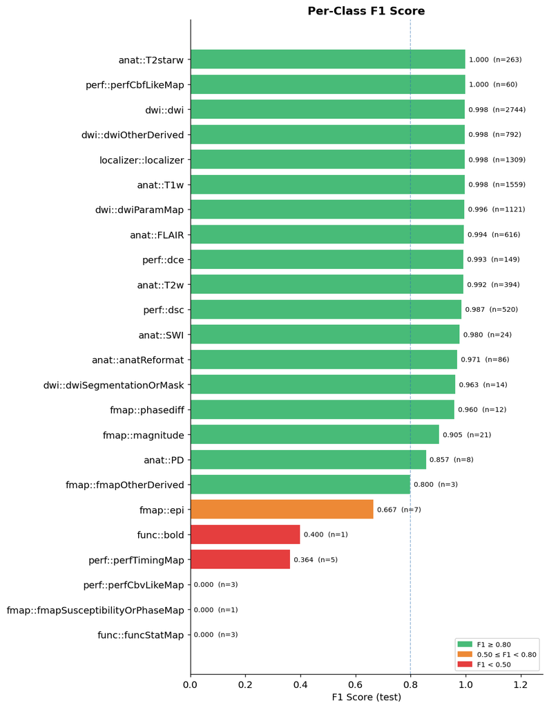

```python
# F1 horizontal bar chart
sorted_report = class_report.sort_values("f1-score")
bar_colors_f1 = [
    "#E53E3E" if f < 0.50 else ("#ED8936" if f < 0.80 else "#48BB78")
    for f in sorted_report["f1-score"]
]
fig, ax = plt.subplots(figsize=(9, len(sorted_report) * 0.44 + 1))
bars = ax.barh(sorted_report["label"], sorted_report["f1-score"],
               color=bar_colors_f1, edgecolor="white")
for bar, (_, row) in zip(bars, sorted_report.iterrows()):
    ax.text(
        min(row["f1-score"] + 0.012, 1.02),
        bar.get_y() + bar.get_height() / 2,
        f"{row['f1-score']:.3f}  (n={int(row['support'])})",
        va="center", fontsize=8,
    )
ax.set_xlim(0, 1.28)
ax.set_xlabel("F1 Score (test)")
ax.set_title("Per-Class F1 Score", fontweight="bold")
ax.axvline(0.80, color="#2B6CB0", linewidth=0.9, linestyle="--", alpha=0.5)
legend_patches = [
    mpatches.Patch(color="#48BB78", label="F1 ≥ 0.80"),
    mpatches.Patch(color="#ED8936", label="0.50 ≤ F1 < 0.80"),
    mpatches.Patch(color="#E53E3E", label="F1 < 0.50"),
]
ax.legend(handles=legend_patches, fontsize=8, loc="lower right")
plt.tight_layout()
plt.show()
plt.close(fig)
```

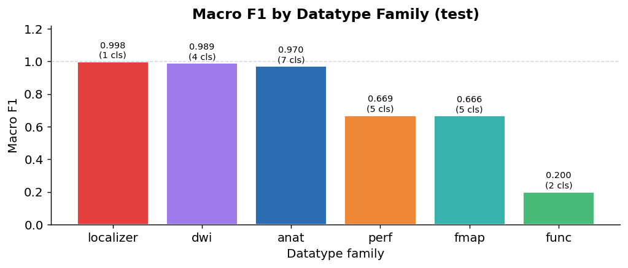

|  | datatype | macro_f1 | n_classes | total_support |
| --- | --- | --- | --- | --- |
| 4 | localizer | 0.9981 | 1 | 1309 |
| 1 | dwi | 0.9890 | 4 | 4671 |
| 0 | anat | 0.9704 | 7 | 2950 |
| 5 | perf | 0.6687 | 5 | 737 |
| 2 | fmap | 0.6663 | 5 | 44 |
| 3 | func | 0.2000 | 2 | 4 |

```python
# Macro F1 by datatype family
family_f1 = (
    class_report.groupby("datatype")
    .agg(
        macro_f1=("f1-score", "mean"),
        n_classes=("label", "count"),
        total_support=("support", "sum"),
    )
    .reset_index()
    .sort_values("macro_f1", ascending=False)
)

fam_colors = [_family_palette.get(d, "#A0AEC0") for d in family_f1["datatype"]]
fig, ax = plt.subplots(figsize=(8, 3.5))
ax.bar(family_f1["datatype"], family_f1["macro_f1"], color=fam_colors, edgecolor="white")
for i, (_, row) in enumerate(family_f1.iterrows()):
    ax.text(i, row["macro_f1"] + 0.012,
            f"{row['macro_f1']:.3f}\n({int(row['n_classes'])} cls)",
            ha="center", va="bottom", fontsize=8)
ax.set_ylim(0, 1.22)
ax.set_xlabel("Datatype family")
ax.set_ylabel("Macro F1")
ax.set_title("Macro F1 by Datatype Family (test)", fontweight="bold")
ax.axhline(1.0, color="#CBD5E0", linewidth=0.8, linestyle="--")
plt.tight_layout()
plt.show()
plt.close(fig)

display(family_f1)
```

## Part 8 — Weak and Low-Support Classes

Some classes have very few test samples (`support ≤ 5`) or F1 below 0.50. These fall into two categories:

1. **Rare acquisitions** — functionally valid BIDS types that are simply uncommon in our dataset (e.g., `func::funcStatMap`, `perf::perfCbvLikeMap`). More training data would close the gap.
2. **Ambiguous sequences** — scan types that share DICOM characteristics with more common types, creating genuine classification difficulty even with more data.

The table below lists every class with `f1-score < 0.80` or `support ≤ 5` in the test set.

```python
weak_classes = class_report[
    (class_report["f1-score"] < 0.80) | (class_report["support"] <= 5)
].sort_values("f1-score")[["label", "datatype", "precision", "recall", "f1-score", "support"]].copy()

print(f"Classes with F1 < 0.80 or support ≤ 5: {len(weak_classes)} / {len(class_report)}")
display(weak_classes.style
    .format({"precision": "{:.3f}", "recall": "{:.3f}", "f1-score": "{:.3f}"})
    .background_gradient(subset=["f1-score"], cmap="RdYlGn")
    .set_caption("Weak / Low-Support Classes")
)

# Val vs test comparison for weak classes
_val_report = report_val[~report_val["label"].isin(_summary_labels)].copy()
_val_report["support"] = _val_report["support"].astype(int)
weak_labels = weak_classes["label"].tolist()
comparison = pd.merge(
    class_report[class_report["label"].isin(weak_labels)][["label", "f1-score", "support"]].rename(
        columns={"f1-score": "f1_test", "support": "support_test"}
    ),
    _val_report[_val_report["label"].isin(weak_labels)][["label", "f1-score", "support"]].rename(
        columns={"f1-score": "f1_val", "support": "support_val"}
    ),
    on="label", how="outer",
).sort_values("f1_test")
print("\nWeak classes — val vs test F1:")
display(comparison)
```

```
Classes with F1 < 0.80 or support ≤ 5: 7 / 24
```

Weak / Low-Support Classes

|  | label | datatype | precision | recall | f1-score | support |
| --- | --- | --- | --- | --- | --- | --- |
| 13 | fmap::fmapSusceptibilityOrPhaseMap | fmap | 0.000 | 0.000 | 0.000 | 1 |
| 17 | func::funcStatMap | func | 0.000 | 0.000 | 0.000 | 3 |
| 22 | perf::perfCbvLikeMap | perf | 0.000 | 0.000 | 0.000 | 3 |
| 23 | perf::perfTimingMap | perf | 0.333 | 0.400 | 0.364 | 5 |
| 16 | func::bold | func | 0.250 | 1.000 | 0.400 | 1 |
| 11 | fmap::epi | fmap | 0.800 | 0.571 | 0.667 | 7 |
| 12 | fmap::fmapOtherDerived | fmap | 1.000 | 0.667 | 0.800 | 3 |

```
Weak classes — val vs test F1:
```

|  | label | f1_test | support_test | f1_val | support_val |
| --- | --- | --- | --- | --- | --- |
| 2 | fmap::fmapSusceptibilityOrPhaseMap | 0.0000 | 1 | 0.0000 | 2.0000 |
| 4 | func::funcStatMap | 0.0000 | 3 | NaN | NaN |
| 5 | perf::perfCbvLikeMap | 0.0000 | 3 | NaN | NaN |
| 6 | perf::perfTimingMap | 0.3636 | 5 | 0.6000 | 5.0000 |
| 3 | func::bold | 0.4000 | 1 | 1.0000 | 2.0000 |
| 0 | fmap::epi | 0.6667 | 7 | 0.3333 | 5.0000 |
| 1 | fmap::fmapOtherDerived | 0.8000 | 3 | 0.5714 | 2.0000 |

## Part 8B — Weak-Class Misidentification Deep Dive

This section answers:

1. Which low-performing classes are being misidentified as what?
2. Are those errors concentrated in one dominant confusion path or spread out?
3. Are mistakes low-confidence (uncertainty) or high-confidence (calibration risk)?

```python
# Build weak-class confusion diagnostics on test split
true_col = "joint_label"
pred_col_export = "ml_pred_joint_label"

# Use only test rows with both true and predicted labels available
test_eval = analysis_df[
    (analysis_df["ml_split"] == "test")
    & analysis_df[true_col].notna()
    & analysis_df[pred_col_export].notna()
].copy()
test_eval["is_correct"] = test_eval[true_col] == test_eval[pred_col_export]

# Recompute weak labels from class_report for reproducibility
weak_labels = set(
    class_report[
        (class_report["f1-score"] < 0.80) | (class_report["support"] <= 5)
    ]["label"].tolist()
)

weak_eval = test_eval[test_eval[true_col].isin(weak_labels)].copy()
weak_errors = weak_eval[~weak_eval["is_correct"]].copy()

confusion_pairs = (
    weak_errors.groupby([true_col, pred_col_export])
    .size()
    .rename("errors")
    .reset_index()
)

true_support = (
    weak_eval.groupby(true_col)
    .size()
    .rename("support")
    .reset_index()
)

weak_confusion_summary = confusion_pairs.merge(true_support, on=true_col, how="left")
weak_confusion_summary["error_share_of_class"] = (
    weak_confusion_summary["errors"] / weak_confusion_summary["support"]
).fillna(0.0)

weak_confusion_summary = weak_confusion_summary.sort_values(
    [true_col, "errors"], ascending=[True, False]
)

print(f"Weak classes on test: {len(weak_labels)}")
print(f"Weak-class test rows: {len(weak_eval):,}")
print(f"Weak-class test errors: {len(weak_errors):,}")

display(
    weak_confusion_summary[[
        true_col, pred_col_export, "errors", "support", "error_share_of_class"
    ]].head(30)
)
```

```
Weak classes on test: 7
Weak-class test rows: 16
Weak-class test errors: 16
```

|  | joint_label | ml_pred_joint_label | errors | support | error_share_of_class |
| --- | --- | --- | --- | --- | --- |
| 1 | fmap::epi | dwi::dwi | 2 | 5 | 0.4000 |
| 0 | fmap::epi | anat::T2starw | 1 | 5 | 0.2000 |
| 2 | fmap::epi | localizer::localizer | 1 | 5 | 0.2000 |
| 3 | fmap::epi | perf::dsc | 1 | 5 | 0.2000 |
| 5 | fmap::fmapOtherDerived | dwi::dwiParamMap | 2 | 3 | 0.6667 |
| 4 | fmap::fmapOtherDerived | dwi::dwiOtherDerived | 1 | 3 | 0.3333 |
| 6 | func::bold | dwi::dwi | 1 | 2 | 0.5000 |
| 7 | func::bold | perf::dsc | 1 | 2 | 0.5000 |
| 8 | func::funcStatMap | dwi::dwi | 1 | 1 | 1.0000 |
| 9 | perf::perfCbvLikeMap | dwi::dwi | 2 | 2 | 1.0000 |
| 10 | perf::perfTimingMap | anat::T1w | 3 | 3 | 1.0000 |

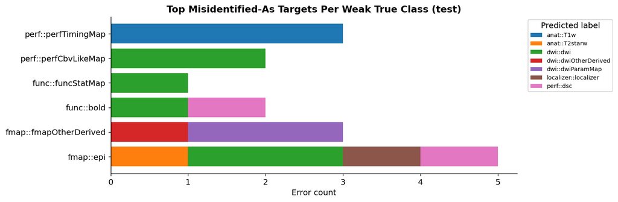

```
Top-1 confusion target per weak class:
```

|  | joint_label | top_misidentified_as | errors | support | error_share_of_class |
| --- | --- | --- | --- | --- | --- |
| 1 | fmap::epi | dwi::dwi | 2 | 5 | 0.4000 |
| 5 | fmap::fmapOtherDerived | dwi::dwiParamMap | 2 | 3 | 0.6667 |
| 6 | func::bold | dwi::dwi | 1 | 2 | 0.5000 |
| 8 | func::funcStatMap | dwi::dwi | 1 | 1 | 1.0000 |
| 9 | perf::perfCbvLikeMap | dwi::dwi | 2 | 2 | 1.0000 |
| 10 | perf::perfTimingMap | anat::T1w | 3 | 3 | 1.0000 |

```python
# Visualize dominant misidentification pathways per weak class
_topk = 5
plot_df = (
    weak_confusion_summary.sort_values([true_col, "errors"], ascending=[True, False])
    .groupby(true_col)
    .head(_topk)
    .copy()
)

if len(plot_df) == 0:
    print("No weak-class errors found on test split.")
else:
    pivot = plot_df.pivot_table(
        index=true_col,
        columns=pred_col_export,
        values="errors",
        aggfunc="sum",
        fill_value=0,
    )

    fig, ax = plt.subplots(figsize=(12, max(4, 0.6 * len(pivot))))
    left = np.zeros(len(pivot))
    y_pos = np.arange(len(pivot))

    for pred_label in pivot.columns:
        values = pivot[pred_label].values
        ax.barh(y_pos, values, left=left, label=pred_label)
        left += values

    ax.set_yticks(y_pos)
    ax.set_yticklabels(pivot.index)
    ax.set_xlabel("Error count")
    ax.set_title("Top Misidentified-As Targets Per Weak True Class (test)", fontweight="bold")
    ax.legend(title="Predicted label", bbox_to_anchor=(1.02, 1), loc="upper left", fontsize=8)
    plt.tight_layout()
    plt.show()
    plt.close(fig)

    top1 = (
        weak_confusion_summary.sort_values([true_col, "errors"], ascending=[True, False])
        .groupby(true_col)
        .head(1)
        [[true_col, pred_col_export, "errors", "support", "error_share_of_class"]]
        .rename(columns={pred_col_export: "top_misidentified_as"})
    )
    print("Top-1 confusion target per weak class:")
    display(top1)
```

```
Confidence summary by weak class and correctness:
```

|  | joint_label | correctness | count | mean | median |
| --- | --- | --- | --- | --- | --- |
| 0 | fmap::epi | incorrect | 5 | 0.9938 | 1.0000 |
| 1 | fmap::fmapOtherDerived | incorrect | 3 | 0.9999 | 0.9999 |
| 2 | func::bold | incorrect | 2 | 0.9989 | 0.9989 |
| 3 | func::funcStatMap | incorrect | 1 | 1.0000 | 1.0000 |
| 4 | perf::perfCbvLikeMap | incorrect | 2 | 1.0000 | 1.0000 |
| 5 | perf::perfTimingMap | incorrect | 3 | 1.0000 | 1.0000 |

```
Support by split for weak classes:
```

| ml_split | joint_label | train | val | test |
| --- | --- | --- | --- | --- |
| 0 | fmap::epi | 27 | 6 | 5 |
| 1 | fmap::fmapOtherDerived | 18 | 1 | 3 |
| 2 | fmap::fmapSusceptibilityOrPhaseMap | 5 | 2 | 0 |
| 3 | func::bold | 4 | 1 | 2 |
| 4 | func::funcStatMap | 3 | 0 | 1 |
| 5 | perf::perfCbvLikeMap | 8 | 0 | 2 |
| 6 | perf::perfTimingMap | 17 | 5 | 3 |

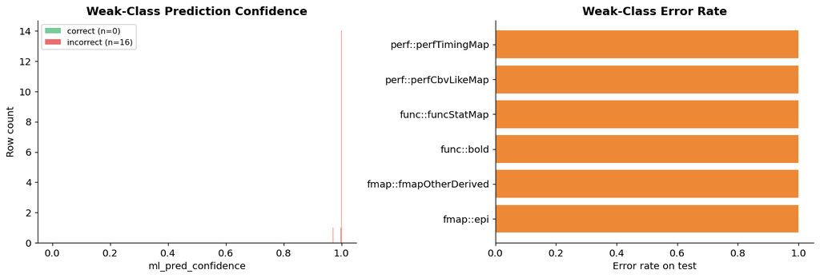

```python
# Confidence and support diagnostics for weak classes
weak_eval = weak_eval.copy()
weak_eval["correctness"] = np.where(weak_eval["is_correct"], "correct", "incorrect")

conf_stats = (
    weak_eval.groupby([true_col, "correctness"])["ml_pred_confidence"]
    .agg(["count", "mean", "median"])
    .reset_index()
    .sort_values([true_col, "correctness"])
)

# Per-class support across train/val/test
split_support = (
    analysis_df[
        analysis_df[true_col].isin(weak_labels)
        & analysis_df["ml_split"].isin(["train", "val", "test"])
    ]
    .groupby([true_col, "ml_split"])
    .size()
    .rename("rows")
    .reset_index()
)

support_wide = split_support.pivot(index=true_col, columns="ml_split", values="rows").fillna(0).astype(int)
for col in ["train", "val", "test"]:
    if col not in support_wide.columns:
        support_wide[col] = 0
support_wide = support_wide[["train", "val", "test"]].reset_index()

print("Confidence summary by weak class and correctness:")
display(conf_stats)

print("Support by split for weak classes:")
display(support_wide)

# Plot confidence distributions: correct vs incorrect for weak classes
fig, axes = plt.subplots(1, 2, figsize=(13, 4.5))

ax = axes[0]
correct_conf = weak_eval.loc[weak_eval["is_correct"], "ml_pred_confidence"].dropna()
incorrect_conf = weak_eval.loc[~weak_eval["is_correct"], "ml_pred_confidence"].dropna()
ax.hist(correct_conf, bins=20, alpha=0.75, label=f"correct (n={len(correct_conf):,})", color="#48BB78")
ax.hist(incorrect_conf, bins=20, alpha=0.75, label=f"incorrect (n={len(incorrect_conf):,})", color="#E53E3E")
ax.set_title("Weak-Class Prediction Confidence", fontweight="bold")
ax.set_xlabel("ml_pred_confidence")
ax.set_ylabel("Row count")
ax.legend(fontsize=9)

ax2 = axes[1]
error_rate_by_class = (
    weak_eval.groupby(true_col)["is_correct"]
    .apply(lambda s: 1 - s.mean())
    .sort_values(ascending=False)
)
ax2.barh(error_rate_by_class.index, error_rate_by_class.values, color="#ED8936")
ax2.set_xlabel("Error rate on test")
ax2.set_title("Weak-Class Error Rate", fontweight="bold")

plt.tight_layout()
plt.show()
plt.close(fig)
```

|  | conf_bucket | rows | accuracy | error_rate |
| --- | --- | --- | --- | --- |
| 0 | 0.0-0.1 | 3 | 0.0000 | 1.0000 |
| 1 | 0.1-0.2 | 0 | NaN | NaN |
| 2 | 0.2-0.3 | 3 | 0.0000 | 1.0000 |
| 3 | 0.3-0.4 | 2 | 0.0000 | 1.0000 |
| 4 | 0.4-0.5 | 0 | NaN | NaN |
| 5 | 0.5-0.6 | 4 | 0.0000 | 1.0000 |
| 6 | 0.6-0.7 | 0 | NaN | NaN |
| 7 | 0.7-0.8 | 3 | 0.0000 | 1.0000 |
| 8 | 0.8-0.9 | 0 | NaN | NaN |
| 9 | 0.9-1.0 | 1 | 0.0000 | 1.0000 |

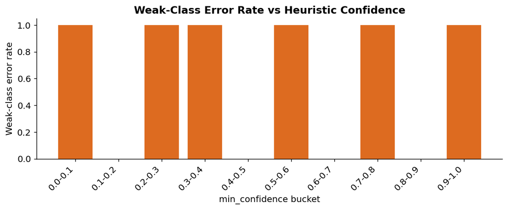

```python
# Weak-class error rate vs heuristic min_confidence bucket
bucket_df = weak_eval.copy()
bucket_df = bucket_df[bucket_df["min_confidence"].notna()].copy()

if len(bucket_df) == 0:
    print("No min_confidence values available for weak-class bucket analysis.")
else:
    bins = np.linspace(0, 1, 11)
    labels = [f"{bins[i]:.1f}-{bins[i+1]:.1f}" for i in range(len(bins) - 1)]
    bucket_df["conf_bucket"] = pd.cut(
        bucket_df["min_confidence"], bins=bins, labels=labels, include_lowest=True
    )
    bucket_stats = (
        bucket_df.groupby("conf_bucket", observed=False)["is_correct"]
        .agg(rows="count", accuracy="mean")
        .reset_index()
    )
    bucket_stats["error_rate"] = 1 - bucket_stats["accuracy"]

    display(bucket_stats)

    fig, ax = plt.subplots(figsize=(9, 3.8))
    ax.bar(bucket_stats["conf_bucket"].astype(str), bucket_stats["error_rate"], color="#DD6B20")
    ax.set_xlabel("min_confidence bucket")
    ax.set_ylabel("Weak-class error rate")
    ax.set_ylim(0, 1.05)
    ax.set_title("Weak-Class Error Rate vs Heuristic Confidence", fontweight="bold")
    plt.xticks(rotation=45, ha="right")
    plt.tight_layout()
    plt.show()
    plt.close(fig)
```

## Part 8C — Stability Across Validation vs Test

This view separates persistent weak classes from split-instability artifacts by comparing validation and test F1 with explicit support counts.

```
Weak-class val/test stability:
```

|  | label | f1_test | support_test | f1_val | support_val | f1_delta_test_minus_val | stability_tag |
| --- | --- | --- | --- | --- | --- | --- | --- |
| 14 | fmap::fmapSusceptibilityOrPhaseMap | 0.0000 | 1.0000 | 0.0000 | 2.0000 | 0.0000 | sparse_support |
| 18 | func::funcStatMap | 0.0000 | 3.0000 | NaN | NaN | NaN | sparse_support |
| 23 | perf::perfCbvLikeMap | 0.0000 | 3.0000 | NaN | NaN | NaN | sparse_support |
| 24 | perf::perfTimingMap | 0.3636 | 5.0000 | 0.6000 | 5.0000 | -0.2364 | stable_weak |
| 17 | func::bold | 0.4000 | 1.0000 | 1.0000 | 2.0000 | -0.6000 | sparse_support |
| 11 | fmap::epi | 0.6667 | 7.0000 | 0.3333 | 5.0000 | 0.3333 | split_instability |
| 12 | fmap::fmapOtherDerived | 0.8000 | 3.0000 | 0.5714 | 2.0000 | 0.2286 | sparse_support |

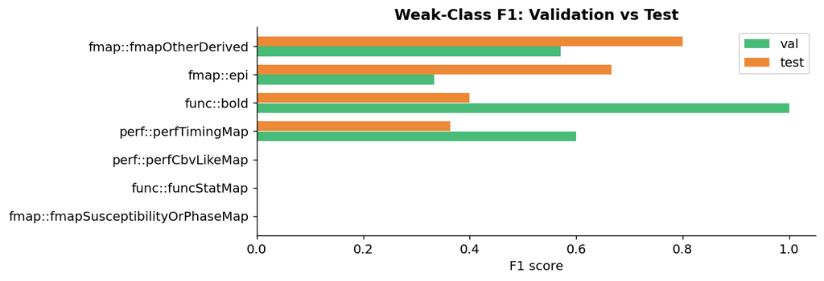

```python
# Validation vs test stability for weak classes
val_cls = report_val[~report_val["label"].isin(_summary_labels)].copy()
val_cls["support"] = val_cls["support"].astype(int)

test_cls = class_report[["label", "f1-score", "support"]].rename(
    columns={"f1-score": "f1_test", "support": "support_test"}
)
val_cls = val_cls[["label", "f1-score", "support"]].rename(
    columns={"f1-score": "f1_val", "support": "support_val"}
)

stability = test_cls.merge(val_cls, on="label", how="outer")
stability = stability[stability["label"].isin(weak_labels)].copy()
stability["f1_delta_test_minus_val"] = stability["f1_test"] - stability["f1_val"]

# Tag interpretation buckets
stability["stability_tag"] = "stable_weak"
stability.loc[
    (stability["support_test"].fillna(0) < 5) | (stability["support_val"].fillna(0) < 5),
    "stability_tag",
] = "sparse_support"
stability.loc[
    (stability["f1_delta_test_minus_val"].abs() > 0.25)
    & ~((stability["support_test"].fillna(0) < 5) | (stability["support_val"].fillna(0) < 5)),
    "stability_tag",
] = "split_instability"

stability = stability.sort_values("f1_test", ascending=True)
print("Weak-class val/test stability:")
display(stability)

fig, ax = plt.subplots(figsize=(10, max(3.5, 0.5 * len(stability))))
y = np.arange(len(stability))
ax.barh(y - 0.18, stability["f1_val"].fillna(0), height=0.35, label="val", color="#48BB78")
ax.barh(y + 0.18, stability["f1_test"].fillna(0), height=0.35, label="test", color="#ED8936")
ax.set_yticks(y)
ax.set_yticklabels(stability["label"])
ax.set_xlim(0, 1.05)
ax.set_xlabel("F1 score")
ax.set_title("Weak-Class F1: Validation vs Test", fontweight="bold")
ax.legend()
plt.tight_layout()
plt.show()
plt.close(fig)
```

```
Dataset-level weak-class error rates:
```

|  | dataset | joint_label | rows | accuracy | error_rate |
| --- | --- | --- | --- | --- | --- |
| 0 | proactive | fmap::epi | 4 | 0.0000 | 1.0000 |
| 1 | proactive | fmap::fmapOtherDerived | 3 | 0.0000 | 1.0000 |
| 2 | proactive | func::bold | 2 | 0.0000 | 1.0000 |
| 3 | proactive | func::funcStatMap | 1 | 0.0000 | 1.0000 |
| 4 | proactive | perf::perfCbvLikeMap | 2 | 0.0000 | 1.0000 |
| 5 | proactive | perf::perfTimingMap | 2 | 0.0000 | 1.0000 |
| 6 | qiac | fmap::epi | 1 | 0.0000 | 1.0000 |
| 7 | qiac | perf::perfTimingMap | 1 | 0.0000 | 1.0000 |

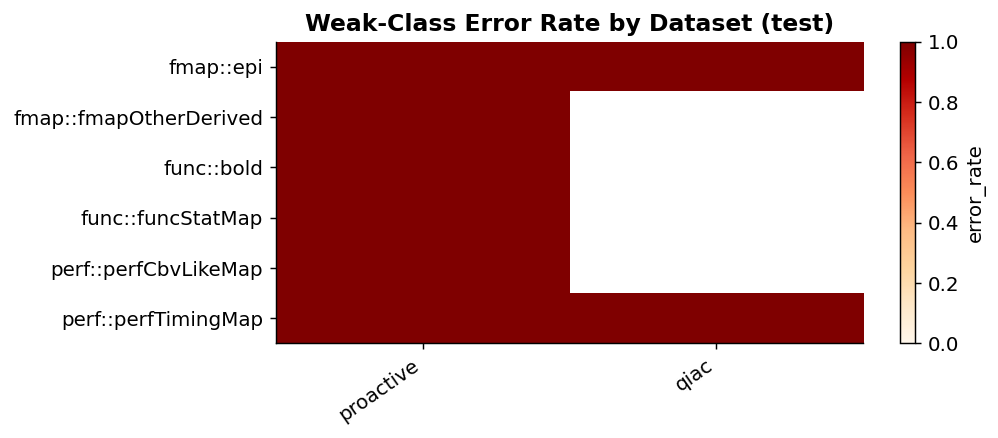

```python
# Dataset/site effect for weak classes on test split
if "dataset" not in weak_eval.columns:
    print("No dataset column available for site-effect analysis.")
else:
    ds_err = (
        weak_eval.groupby(["dataset", true_col])["is_correct"]
        .agg(rows="count", accuracy="mean")
        .reset_index()
    )
    ds_err["error_rate"] = 1 - ds_err["accuracy"]
    ds_err = ds_err.sort_values(["dataset", "error_rate"], ascending=[True, False])

    print("Dataset-level weak-class error rates:")
    display(ds_err)

    pivot = ds_err.pivot(index=true_col, columns="dataset", values="error_rate")
    fig, ax = plt.subplots(figsize=(8, max(3.5, 0.55 * len(pivot))))
    im = ax.imshow(pivot.fillna(np.nan).values, aspect="auto", cmap="OrRd", vmin=0, vmax=1)
    ax.set_yticks(np.arange(len(pivot.index)))
    ax.set_yticklabels(pivot.index)
    ax.set_xticks(np.arange(len(pivot.columns)))
    ax.set_xticklabels(pivot.columns, rotation=35, ha="right")
    ax.set_title("Weak-Class Error Rate by Dataset (test)", fontweight="bold")
    cbar = fig.colorbar(im, ax=ax)
    cbar.set_label("error_rate")
    plt.tight_layout()
    plt.show()
    plt.close(fig)
```

## Part 9 — Confusion Analysis

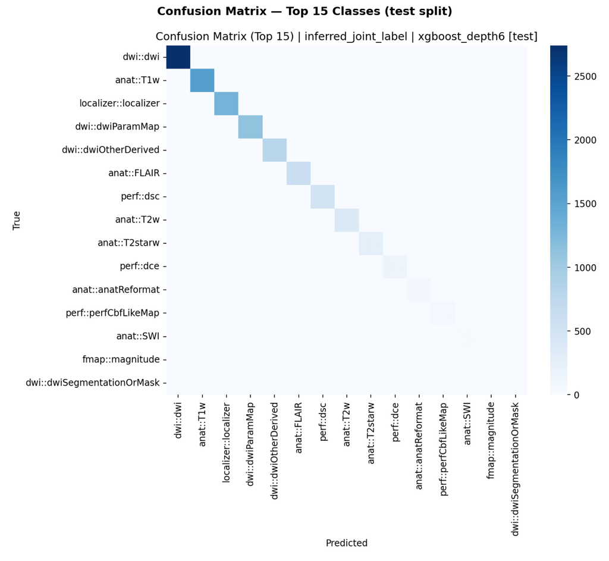

```python
confusion_img_path = CONFUSION_DIR / "confusion_top15_inferred_joint_label_test.png"
if confusion_img_path.exists():
    img = mpimg.imread(str(confusion_img_path))
    fig, ax = plt.subplots(figsize=(11, 9))
    ax.imshow(img)
    ax.axis("off")
    ax.set_title("Confusion Matrix — Top 15 Classes (test split)", fontweight="bold", pad=12)
    plt.tight_layout()
    plt.show()
    plt.close(fig)
else:
    print(f"Image not found: {confusion_img_path}")
    print("Re-run ml.ipynb cell #VSC-c5d18b69 to generate it.")
```

## Part 10 — Unknown-Label Inference

Series that the heuristic engine could not label confidently (either `inferred_datatype` or `inferred_suffix` is `unknown`) were **excluded from supervised training** but were **scored by the final model** in a separate inference pass.

The review below shows what the model predicts for these heuristically ambiguous series and how confident those predictions are. High-confidence ML predictions on unknown-heuristic rows are strong candidates for accepting as BIDS labels — or for routing to human review with a suggested label.

```python
print(f"Unknown-heuristic series scored by ML: {len(unknown_review):,}")
display(unknown_review[[
    "dataset", "subject_id",
    # "series_id",
    "series_description",
    "inferred_datatype", "inferred_suffix", "min_confidence",
    "pred_inferred_joint_label", "pred_inferred_joint_label_confidence",
]].head(15))
```

```
Unknown-heuristic series scored by ML: 12,527
```

|  | dataset | subject_id | series_description | inferred_datatype | inferred_suffix | min_confidence | pred_inferred_joint_label | pred_inferred_joint_label_confidence |
| --- | --- | --- | --- | --- | --- | --- | --- | --- |
| 0 | proactive | 1022-1937 | Ax T1 | anat | unknown | 0.0000 | anat::T1w | 0.8587 |
| 1 | proactive | 1022-1937 | Ax DWI_TRACEW | dwi | unknown | 0.0000 | anat::T1w | 0.8193 |
| 2 | proactive | 1022-1937 | Ax DTI_TRACEW | dwi | unknown | 0.0000 | dwi::dwiParamMap | 0.9025 |
| 3 | proactive | 1022-1937 | Trace:Sep 12 2023 12-09-32 CDT | dwi | unknown | 0.0000 | anat::T1w | 0.8424 |
| 4 | proactive | 1022-1937 | AvDC:Sep 12 2023 12-09-33 CDT | dwi | unknown | 0.0000 | dwi::dwiOtherDerived | 0.5445 |
| 5 | proactive | 1022-1937 | Universal:352:AvDC:Sep 12 2023 12-09-33 CDT | dwi | unknown | 0.0000 | anat::FLAIR | 0.6249 |
| 6 | proactive | 1022-1937 | Trace:Jul 14 2023 16-46-39 CDT | dwi | unknown | 0.0000 | dwi::dwiParamMap | 0.8388 |
| 7 | proactive | 1022-1937 | AvDC:Jul 14 2023 16-46-41 CDT | dwi | unknown | 0.0000 | anat::T1w | 0.8442 |
| 8 | proactive | 1022-1937 | Universal:552:AvDC:Jul 14 2023 16-46-41 CDT | dwi | unknown | 0.0000 | anat::FLAIR | 0.4768 |
| 9 | proactive | 1022-1937 | COL:MRA Head | dwi | unknown | 0.0000 | perf::perfCbfLikeMap | 0.6576 |
| 10 | proactive | 1022-1937 | Axial MIP 10_1 | dwi | unknown | 0.0000 | anat::FLAIR | 0.6561 |
| 11 | proactive | 1022-1937 | Sag MIP 10_1 | dwi | unknown | 0.0000 | anat::FLAIR | 0.4392 |
| 12 | proactive | 1022-1937 | Cor MIP 10_1 | dwi | unknown | 0.0000 | perf::perfCbfLikeMap | 0.6935 |
| 13 | proactive | 1022-1937 | AvDC:Jul 18 2023 20-20-16 CDT | dwi | unknown | 0.0000 | anat::T1w | 0.8563 |
| 14 | proactive | 1022-1937 | Universal:352:AvDC:Jul 18 2023 20-20-16 CDT | dwi | unknown | 0.0000 | anat::T1w | 0.8371 |

### Weak-Class Opportunity In Unknown-Heuristic Series

How often does the model predict weak classes on unknown-heuristic rows, and at what confidence? This identifies candidates for targeted human review and class expansion.

```
Unknown rows predicted as weak classes: 55
```

|  | pred_inferred_joint_label | rows | mean_conf | median_conf | ge_090 | ge_095 | pct_ge_090 | pct_ge_095 |
| --- | --- | --- | --- | --- | --- | --- | --- | --- |
| 2 | func::bold | 19 | 0.1977 | 0.1930 | 0 | 0 | 0.0000 | 0.0000 |
| 1 | fmap::fmapOtherDerived | 17 | 0.4080 | 0.3653 | 0 | 0 | 0.0000 | 0.0000 |
| 0 | fmap::epi | 13 | 0.3128 | 0.2795 | 0 | 0 | 0.0000 | 0.0000 |
| 3 | perf::perfCbvLikeMap | 3 | 0.6676 | 0.7287 | 0 | 0 | 0.0000 | 0.0000 |
| 4 | perf::perfTimingMap | 3 | 0.3849 | 0.3564 | 0 | 0 | 0.0000 | 0.0000 |

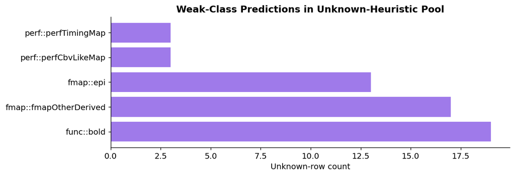

```python
# Unknown-series opportunities for weak classes
unknown_pred_col = "pred_inferred_joint_label"
unknown_conf_col = "pred_inferred_joint_label_confidence"

weak_unknown = unknown_review[
    unknown_review[unknown_pred_col].isin(weak_labels)
].copy()

if len(weak_unknown) == 0:
    print("No unknown-heuristic rows predicted as weak classes.")
else:
    weak_unknown_summary = (
        weak_unknown.groupby(unknown_pred_col)[unknown_conf_col]
        .agg(
            rows="count",
            mean_conf="mean",
            median_conf="median",
            ge_090=lambda s: (s >= 0.90).sum(),
            ge_095=lambda s: (s >= 0.95).sum(),
        )
        .reset_index()
        .sort_values("rows", ascending=False)
    )
    weak_unknown_summary["pct_ge_090"] = weak_unknown_summary["ge_090"] / weak_unknown_summary["rows"]
    weak_unknown_summary["pct_ge_095"] = weak_unknown_summary["ge_095"] / weak_unknown_summary["rows"]

    print(f"Unknown rows predicted as weak classes: {len(weak_unknown):,}")
    display(weak_unknown_summary)

    fig, ax = plt.subplots(figsize=(10, max(3.5, 0.5 * len(weak_unknown_summary))))
    ax.barh(weak_unknown_summary[unknown_pred_col], weak_unknown_summary["rows"], color="#9F7AEA")
    ax.set_xlabel("Unknown-row count")
    ax.set_title("Weak-Class Predictions in Unknown-Heuristic Pool", fontweight="bold")
    plt.tight_layout()
    plt.show()
    plt.close(fig)
```

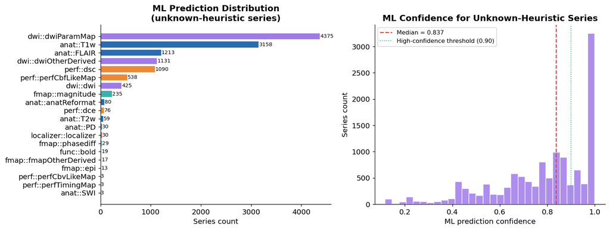

```
ML confidence ≥ 0.90: 4,460 / 12,527  (35.6%)
Median confidence   : 0.8371
Mean confidence     : 0.7805
```

```python
pred_col  = "pred_inferred_joint_label"
conf_col  = "pred_inferred_joint_label_confidence"

pred_counts = unknown_review[pred_col].value_counts().head(20).sort_values()
pred_dtypes = pred_counts.index.str.split("::").str[0]
pred_colors = [_family_palette.get(d, "#A0AEC0") for d in pred_dtypes]

fig, axes = plt.subplots(1, 2, figsize=(13, 5))

ax = axes[0]
ax.barh(pred_counts.index, pred_counts.values, color=pred_colors, edgecolor="white")
for i, v in enumerate(pred_counts.values):
    ax.text(v + 0.3, i, str(v), va="center", fontsize=8)
ax.set_xlabel("Series count")
ax.set_title("ML Prediction Distribution\n(unknown-heuristic series)", fontweight="bold")

ax2 = axes[1]
conf_vals = unknown_review[conf_col].dropna()
ax2.hist(conf_vals, bins=30, color="#9F7AEA", edgecolor="white", alpha=0.85)
ax2.axvline(conf_vals.median(), color="#E53E3E", linewidth=1.5, linestyle="--",
            label=f"Median = {conf_vals.median():.3f}")
ax2.axvline(0.90, color="#48BB78", linewidth=1.2, linestyle=":",
            label="High-confidence threshold (0.90)")
ax2.set_xlabel("ML prediction confidence")
ax2.set_ylabel("Series count")
ax2.set_title("ML Confidence for Unknown-Heuristic Series", fontweight="bold")
ax2.legend(fontsize=9)

plt.tight_layout()
plt.show()
plt.close(fig)

high_conf_n = int((conf_vals >= 0.90).sum())
print(f"ML confidence ≥ 0.90: {high_conf_n:,} / {len(conf_vals):,}  ({high_conf_n/len(conf_vals)*100:.1f}%)")
print(f"Median confidence   : {conf_vals.median():.4f}")
print(f"Mean confidence     : {conf_vals.mean():.4f}")
```

```python
# High-confidence ML predictions — candidates for auto-accepting as BIDS labels
high_conf_rows = unknown_review[unknown_review[conf_col] >= 0.90].sort_values(conf_col, ascending=False)
print(f"High-confidence ML predictions (confidence ≥ 0.90): {len(high_conf_rows):,} rows")
display(high_conf_rows[[
    "dataset", "series_id",
    "inferred_datatype", "inferred_suffix",
    "series_description",
    pred_col, conf_col,
]].head(20))
```

```
High-confidence ML predictions (confidence ≥ 0.90): 4,460 rows
```

|  | dataset | series_id | inferred_datatype | inferred_suffix | series_description | pred_inferred_joint_label | pred_inferred_joint_label_confidence |
| --- | --- | --- | --- | --- | --- | --- | --- |
| 12232 | qiac | 1.3.12.2.1107.5.2.50.176522.300000250806172503... | anat | unknown | Ax T1 | dwi::dwiParamMap | 1.0000 |
| 4466 | proactive | 1.2.840.113619.2.408.5.14196467.865465.19502.1... | dwi | unknown | Universal:452:AvDC:Dec 14 2023 16-32-24 CST | dwi::dwiParamMap | 1.0000 |
| 6226 | qiac | 1.3.12.2.1107.5.2.18.142582.300000250601095642... | anat | unknown | Ax T1 | dwi::dwiParamMap | 1.0000 |
| 5863 | proactive | 1.3.12.2.1107.5.2.50.176519.202309292201159345... | unknown | unknown | PhoenixZIPReport | dwi::dwiParamMap | 1.0000 |
| 1292 | proactive | 1.3.12.2.1107.5.2.18.52113.2023010508273779931... | dwi | unknown | Ax DTI_TRACEW | dwi::dwiParamMap | 1.0000 |
| 8839 | qiac | 1.2.840.113619.2.80.0.23910.1745459832.63.13.2 | dwi | unknown | AvDC (10^-6 mm²/s): b1000 | dwi::dwiParamMap | 1.0000 |
| 2724 | proactive | 1.2.840.113619.2.80.3037550886.1207.1662679678... | dwi | unknown | MRV SPIN | dwi::dwiParamMap | 1.0000 |
| 781 | proactive | 1.2.840.113619.2.80.2077619178.1179.1639089091... | dwi | unknown | AvDC:Dec 09 2021 16-31-31 CST | dwi::dwiParamMap | 1.0000 |
| 12317 | qiac | 1.2.840.113619.2.80.0.15015.1746049600.63.13.2 | dwi | unknown | AvDC (10^-6 mm²/s): b1000 | dwi::dwiParamMap | 1.0000 |
| 2717 | proactive | 1.2.840.113619.2.80.3037550886.30935.166267905... | dwi | unknown | MRA HEAD TUMBLE | dwi::dwiParamMap | 1.0000 |
| 3449 | proactive | 2.25.114510977345967483199948353585188022550 | fmap | unknown | EvaSeries_GLM | dwi::dwiParamMap | 1.0000 |
| 11047 | qiac | 1.3.12.2.1107.5.2.18.141126.300000250710181617... | unknown | unknown | Perfusion_Weighted | dwi::dwiParamMap | 1.0000 |
| 4188 | proactive | 1.3.12.2.1107.5.2.18.52115.2023081007050054552... | dwi | unknown | Ax DTI_TRACEW | dwi::dwiParamMap | 1.0000 |
| 2571 | proactive | 1.2.840.113619.2.80.0.54150.1675882666.69.13.2 | dwi | unknown | AvDC (10^-6 mm²/s)[No-Q] | dwi::dwiParamMap | 1.0000 |
| 12485 | qiac | 1.3.12.2.1107.5.2.18.52115.3000002507171101377... | anat | unknown | +C Ax T1 | dwi::dwiParamMap | 1.0000 |
| 4830 | proactive | 1.3.12.2.1107.5.2.18.52107.2024012207433252672... | anat | unknown | +C Ax T1 | dwi::dwiParamMap | 1.0000 |
| 12481 | qiac | 1.2.840.113619.2.80.0.12498.1757010811.105.13.2 | dwi | unknown | AvDC (10^-6 mm²/s): b1000 | dwi::dwiParamMap | 1.0000 |
| 12399 | qiac | 1.3.12.2.1107.5.2.18.152222.300000250604124847... | unknown | unknown | Perfusion_Weighted | dwi::dwiParamMap | 1.0000 |
| 8823 | qiac | 1.3.12.2.1107.5.2.18.142098.300000250731125113... | unknown | unknown | ASL Color | dwi::dwiParamMap | 1.0000 |
| 1005 | proactive | 1.3.6.1.4.1.34261.3.181124907717723.15.27400.2... | dwi | unknown | DynaSuite SurgicalNavigation_fibers-3DT1 | dwi::dwiParamMap | 1.0000 |

## Part 11 — Localizer Normalization

A dedicated pre-training normalization step converts `localizer::unknown` (series the heuristic identifies as a localizer but cannot assign a specific suffix) to the canonical `localizer::localizer` label.

Without this step, the most common localizer subtype would be silently dropped by the `drop_unknown_in_train_val` filter, starving the model of localizer training signal.

```python
localizer_rows = analysis_df[
    analysis_df["inferred_datatype"].fillna("").str.lower().eq("localizer")
]
vc_loc = localizer_rows["joint_label"].value_counts()
loc_dist = pd.DataFrame({"joint_label": vc_loc.index, "count": vc_loc.values})
print(f"Total localizer-family rows: {len(localizer_rows):,}")
display(loc_dist)

if "localizer::localizer" in class_report["label"].values:
    loc_row = class_report[class_report["label"] == "localizer::localizer"].iloc[0]
    print(
        f"\nlocalizer::localizer test — "
        f"precision={loc_row['precision']:.3f}, recall={loc_row['recall']:.3f}, "
        f"F1={loc_row['f1-score']:.3f}, support={int(loc_row['support'])}"
    )
```

```
Total localizer-family rows: 16,340
```

|  | joint_label | count |
| --- | --- | --- |
| 0 | localizer::localizer | 16340 |

```
localizer::localizer test — precision=1.000, recall=0.996, F1=0.998, support=1309
```

## Key Takeaways

### Recommended Next Steps

1. Collect more labeled examples for rare classes (`func::funcStatMap`, `perf::perfCbvLikeMap`, `perf::perfTimingMap`, `fmap::fmapSusceptibilityOrPhaseMap`)
2. Run human review on unknown-label series with ML confidence ≥ 0.90 to expand the labeled dataset
3. Consider adding prediction calibration (Platt scaling or isotonic regression) to improve the reliability of confidence scores for downstream decision thresholds